# Supplementary Materials

Tyrel Stokes

March 18, 2020

This markdown document contains the code to reproduce the simulations in the article Causal Simulations: Lessons from Bias Amplifications. In addition to the figure code, there is code to easily simulate from all of the DAGs in article. Displayed is the code setting the parameters. The background code to simulate the data can be seen by accessing the r markdown document directly. For presentation, the background code is set to not echo. Similarly, there may be cosmetic differences in the graphs displayed in this r markdown document than those in the paper and in some cases the sample size and replications for the simulation experiments is smaller so the document compiles faster, but the underlying data is generated in an identical way. The context for the simulations is not elaborated on here as this is meant to be a companion for the text. Feel free to use and adapt this code to perform other simulations.

### Simulation 1: Figure 2 in the article

This is the code to produce simulations like those in figure 2, simulating from the Meyers (2011) DAG as shown in figure 1 and the structural equations (1), (2), and (3) from the text reproduced below.

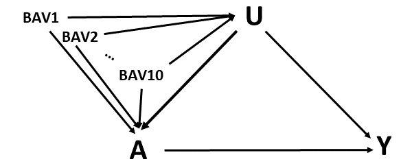

$$\begin{align}
\boldsymbol{Y} &= \alpha_y + \boldsymbol{A}\beta_a + \boldsymbol{U}\beta_u + \epsilon_1\label{eq1: big meyers}, \\
\boldsymbol{A} &= \alpha_a + \boldsymbol{U}\gamma_u + \sum_{i=1}^{10}\boldsymbol{BAV_i}\gamma_{bav_i} + \epsilon_2\label{eq2: big meyers}, \\
\boldsymbol{U} &= \alpha_u + \sum_{i=1}^{10}\boldsymbol{BAV_i}\psi_{bav_i} + \epsilon_3, \label{eq3: big meyers}
\end{align}$$

```r
### These parameters refer to the coefficients in the equations above
psi_bav <- c(-0.55,-0.45,-0.3,0.3,0.25,0.2,-0.2,0.2,-0.15,0.10) ### The coefficients from BAV to U
gamma_bav <- c(-0.1,-0.15, -0.1,0.21,-0.2,0.3,-0.2,-0.15,-0.2,0.075) ### The coefficients from
Ba <- 0.7 # true treatment effect
Bu <- -0.5 # unmeasured confounding from
gamma_u <- 0.59


## Below sets the true standard deviations. The code can be easily adapted to allow the BAVs to have
## different standard deviations and means in the meyers simfunction code block above.
sigBAV <- 1
sigY <- 1
sigU <- 1
sigA <- 1

# Set the intercept terms
alpha_a <- 0
alpha_u <- 0
alpha_bav <- 0
alpha_y <- 0
###############################################################################
N <- 500 # number of simulation replications. N = 5000 was used in the paper
n <- 500 # sample size in each replication. n = 5000 was used in the paper
###################################
```

Now that the parameter values are set, you can use the function meyers_check to make sure your parameters are valid. By valid meaning that they are feasible given the variances you set for the different variables. If the parameters are valid, the below code will show you the expected estimates and absolute bias of the estimates from the unbiased ($Y \sim A + U$), naive ($Y A $), and conditional model ($Y A + BAV$). These expectations are exact when the underlying distributions are all normal. They remain valid in the probability limit if one is to alter the distributions in the simulation code.

If the parameters are not valid, the code will tell you which of the variances is not feasible. Then you may adjust the variances or the parameters underlying the variance to ensure a valid simulation.

```r
meyers_check(sigBAV,sigY, sigA, sigU, alpha_a, alpha_u, alpha_bav,
                       gamma_bav,psi_bav,n,Ba,Bu,gamma_u)
```

```
## [1] "Valid Parameters"
##    Unbiased Model       Naive Model Conditional Model
##        0.70000000        0.26850000       -0.04036893
##    Unbiased Model abs Bias       Naive Model abs Bias
##                  0.0000000                  0.4315000
## Conditional Model abs Bias
##                  0.7403689
```

```r
results_un <- data.frame(matrix(nrow = N, ncol =2))
results_naive <- data.frame(matrix(nrow = N, ncol =2))
results_bav <- data.frame(matrix(nrow = N, ncol =2))

names(results_un) <- c("Estimates","Model")
names(results_naive) <- c("Estimates","Model")
names(results_bav) <- c("Estimates","Model")

results_un$Model <- "Y ~ A + U"
results_naive$Model <- "Y ~ A"
results_bav$Model <- "Y ~ A + BAV"

for(i in 1:N){
meyers_sim(sigBAV,sigY, sigA, sigU, alpha_a, alpha_u, alpha_bav,
                       gamma_bav,psi_bav,n,Ba,Bu,gamma_u)

 mod1 <- lm(Y ~ A + U) ## unbiased model
 mod2 <- lm(Y ~ A)     ## niave model
 mod3 <- lm(Y ~ A + bav) ## conditional model

 results_un[i,1] <- coef(mod1)[2]
 results_naive[i,1] <- coef(mod2)[2]
 results_bav[i,1] <- coef(mod3)[2]
}

results <- rbind(results_un,results_naive,results_bav)
#apply(results,2,mean)
```

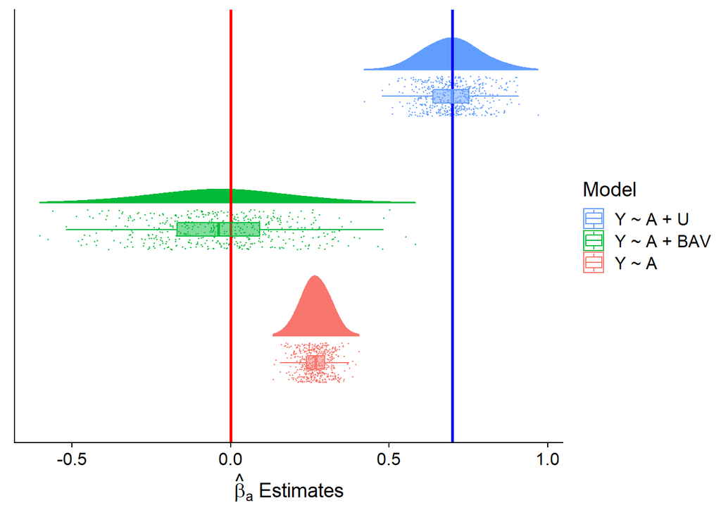

```r
## If the zero = TRUE, the graph will display a vertical line at zero
## This is useful for visualizing incorrectly signed estimates
## with respect to the true value Ba (vertical line in blue)
raincloud_meyers_sim(results,Ba, zero =TRUE)
```

And below we compare the average estimates from the simulations with the expectations (or probability limits).

```r
sim_est <- aggregate(results$Estimates, by = list(results$Model), FUN = mean)
#sim_est
names(sim_est) <-c("Model", "Simulated Estimates")
out <- merge(sim_est,Meyers_Exp)
print(xtable(out), type = "html")
```

|  | Model | Simulated Estimates | expectation |
| --- | --- | --- | --- |
| 1 | Y ~ A | 0.27 | 0.27 |
| 2 | Y ~ A + BAV | -0.03 | -0.04 |
| 3 | Y ~ A + U | 0.70 | 0.70 |

For the expectations to be arbitrarily close increase N for any fixed $n > p$ (default $p=12$). For probability limits to be arbitrarily close, you will have to increase n. The table is generated with xtable and default is to round to 2 decimal places but this can be modified.

### Figure 4 in the Text

This figure shows the geometry of bias amplification. In particular we appeal to the FWL theorem to represent the multi-variable regression as a simple regression of a projected outcome and treatment.

The figure is simulated from the following DAG and set of structural equations:

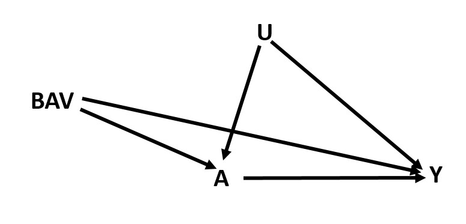

$$\begin{align}
\boldsymbol{Y} &= \alpha_y + \boldsymbol{A}\beta_a + \boldsymbol{U}\beta_u +\boldsymbol{BAV}\boldsymbol{\beta_{bav}} + \boldsymbol{\epsilon_1}\label{Y truth}\\
\boldsymbol{A} &= \alpha_a + \boldsymbol{U}\gamma_u + \boldsymbol{BAV}\boldsymbol{\gamma_{bav}} + \boldsymbol{\epsilon_2}\label{A truth}
\end{align}$$

```r
Ba <- 0.2
Bu <- 0.5
B_bav <- 0.05

gamma_u <- 0.3
gamma_bav <- 0.75

alpha_y <- 2
alpha_u <- 1

sigY <- 1
sigA <- 1
sigU <- 1
sigBAV <- 1

n <- 1000
```

According to the FWL theorem, regressions from the following set of equations are numerically equivalent

$$\begin{align}
\boldsymbol{Y} &= \alpha_y + \boldsymbol{A}\beta_a + \boldsymbol{\upsilon_1}\label{regression1}\\
\boldsymbol{M_{\boldsymbol{1}}Y} &= \boldsymbol{M_{\boldsymbol{1}}A}\beta_a + \boldsymbol{\upsilon_1}\label{eq:modified}
\end{align}$$

Here we will simulate data from the equations with the above parameters and show they are numerically equivalent.

```r
normaldag_sim(Ba,Bu,B_bav,gamma_u,gamma_bav,n,alpha_a,alpha_bav,alpha_u,alpha_y,
                          sigU,sigBAV,sigA,sigY)

mod1 <- lm(Y ~ A)

one <- rep(1,n)
M1 <- diag(one) - one%*%(solve(crossprod(one)))%*%t(one)

M1_Y <- M1 %*%Y
M1_A <- M1 %*%A

mod2 <- lm(M1_Y ~ -1 + M1_A)

summary(mod1)
```

```
##
## Call:
## lm(formula = Y ~ A)
##
## Residuals:
##      Min       1Q   Median       3Q      Max
## -2.69120 -0.70084  0.04215  0.64984  3.01717
##
## Coefficients:
##             Estimate Std. Error t value Pr(>|t|)
## (Intercept)  2.50561    0.03183   78.73   <2e-16 ***
## A            0.37726    0.03039   12.41   <2e-16 ***
## ---
## Signif. codes:  0 '***' 0.001 '**' 0.01 '*' 0.05 '.' 0.1 ' ' 1
##
## Residual standard error: 0.9495 on 998 degrees of freedom
## Multiple R-squared:  0.1337, Adjusted R-squared:  0.1329
## F-statistic: 154.1 on 1 and 998 DF,  p-value: < 2.2e-16
```

```r
summary(mod2)
```

```
##
## Call:
## lm(formula = M1_Y ~ -1 + M1_A)
##
## Residuals:
##      Min       1Q   Median       3Q      Max
## -2.69120 -0.70084  0.04215  0.64984  3.01717
##
## Coefficients:
##      Estimate Std. Error t value Pr(>|t|)
## M1_A  0.37726    0.03038   12.42   <2e-16 ***
## ---
## Signif. codes:  0 '***' 0.001 '**' 0.01 '*' 0.05 '.' 0.1 ' ' 1
##
## Residual standard error: 0.949 on 999 degrees of freedom
## Multiple R-squared:  0.1337, Adjusted R-squared:  0.1329
## F-statistic: 154.2 on 1 and 999 DF,  p-value: < 2.2e-16
```

Notice that the $\beta_a$ estimates are equivalent as well as the residual summary.

Similarly regressions form the following two equations are equivalent, where $Z = [1, BAV]$:

$$\begin{align}
\boldsymbol{Y} &= \alpha_y + \boldsymbol{A}\beta_a + \boldsymbol{BAV}\beta_{bav} + \boldsymbol{\upsilon_2}\label{eq:cond2}\\
\boldsymbol{M_zY} &= \boldsymbol{M_zA}\beta_a + \boldsymbol{\upsilon_2}\label{eq:cond modified}
\end{align}$$

```r
mod3 <- lm(Y ~ A + bav)

Z <- cbind(one,bav)
MZ <- diag(one) - Z%*%(solve(crossprod(Z)))%*%t(Z)

MZ_Y <- MZ%*%Y
MZ_A <- MZ%*%A

mod4 <- lm(MZ_Y ~ -1 + MZ_A)

summary(mod3)
```

```
##
## Call:
## lm(formula = Y ~ A + bav)
##
## Residuals:
##      Min       1Q   Median       3Q      Max
## -2.74441 -0.68407  0.03342  0.63567  2.83378
##
## Coefficients:
##             Estimate Std. Error t value Pr(>|t|)
## (Intercept)  2.46006    0.03373  72.939  < 2e-16 ***
## A            0.50545    0.04482  11.276  < 2e-16 ***
## bav         -0.17349    0.04485  -3.868 0.000117 ***
## ---
## Signif. codes:  0 '***' 0.001 '**' 0.01 '*' 0.05 '.' 0.1 ' ' 1
##
## Residual standard error: 0.9429 on 997 degrees of freedom
## Multiple R-squared:  0.1465, Adjusted R-squared:  0.1448
## F-statistic: 85.59 on 2 and 997 DF,  p-value: < 2.2e-16
```

```r
summary(mod4)
```

```
##
## Call:
## lm(formula = MZ_Y ~ -1 + MZ_A)
##
## Residuals:
##      Min       1Q   Median       3Q      Max
## -2.74441 -0.68407  0.03342  0.63567  2.83378
##
## Coefficients:
##      Estimate Std. Error t value Pr(>|t|)
## MZ_A  0.50545    0.04478   11.29   <2e-16 ***
## ---
## Signif. codes:  0 '***' 0.001 '**' 0.01 '*' 0.05 '.' 0.1 ' ' 1
##
## Residual standard error: 0.942 on 999 degrees of freedom
## Multiple R-squared:  0.1131, Adjusted R-squared:  0.1122
## F-statistic: 127.4 on 1 and 999 DF,  p-value: < 2.2e-16
```

Now we will construct the plot in figure 4 of the text

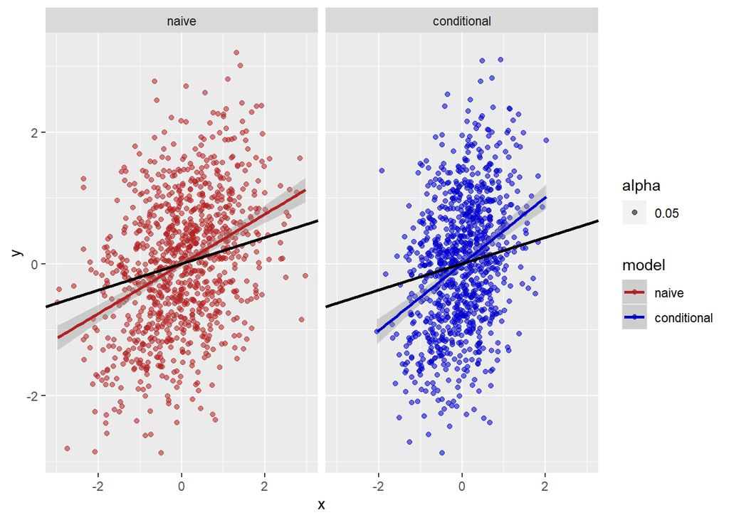

```r
plot_fig4(df,Ba)
```

By changing the underlying parameters you can visualize variance from the treatment and outcome being explained by the covariates in the model.

### Figure 6

There are two parts to figure 6. First the code to produce figure 6 a.

```r
N <- 1000
n <- 100

#out_mat <- matrix(nrow=N,ncol=3,0)

Ba <- .2
Bu <- 0.3
B_bav <- -0.05

gamma_bav <- .6
gu1 <- 0.3 # The original or control gamma_u parameter
gu2 <- 0.55 # The treatment gamma_u


alpha_a <- 0
alpha_bav <- 0
alpha_u <- 0
alpha_y <- 0

sigBAV <- 1
sigU <- 1
sigA <- 1
sigY <- 1


sigA1 <- 1 # Baseline variance
sigA2 <- sqrt((sigA^2 + (gu2^2-gu1^2)*sigU^2)) # Floating Treatment Variance
sigY2 <- sqrt(sigY^2 + Ba^2*(sigA2^2 - sigA1^2) + 2*Ba*Bu*sigU^2*(gu2 - gu1)) # Floating Outcome Variance
```

```r
for(i in 1:N){

  normaldag_sim(Ba,Bu,B_bav,gu1,gamma_bav,n,alpha_a,alpha_bav,alpha_u,alpha_y,
                sigU,sigBAV,sigA1,sigY)
  mod1 <- lm(Y ~ A + bav)

  mod_n1 <- lm(Y ~ A)

  normaldag_sim(Ba,Bu,B_bav,gu2,gamma_bav,n,alpha_a,alpha_bav,alpha_u,alpha_y,
                sigU,sigBAV,sigA1,sigY)

  mod2 <- lm(Y ~ A + bav)
  mod_n2 <- lm(Y ~ A)

  normaldag_sim(Ba,Bu,B_bav,gu2,gamma_bav,n,alpha_a,alpha_bav,alpha_u,alpha_y,
                sigU,sigBAV,sigA2,sigY2)

  mod3 <- lm(Y ~ A + bav)
  mod_n3 <- lm(Y ~ A)

  mat_a[i,1] <- coef(mod1)[2]
  mat_b[i,1] <- coef(mod2)[2]
  mat_c[i,1] <- coef(mod3)[2]



  mat_a1[i,1] <- coef(mod_n1)[2]
  mat_b1[i,1] <- coef(mod_n2)[2]
  mat_c1[i,1] <- coef(mod_n3)[2]

}

results_fig6 <- rbind(mat_a,mat_b,mat_c,mat_a1,mat_b1,mat_c1)
```

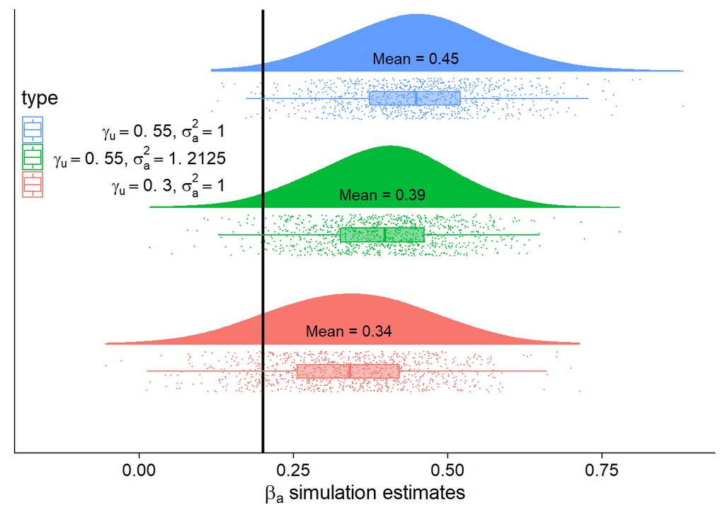

```r
fig6_fun(results_fig6,Ba, sigA1,sigA2,gu1,gu2)
```

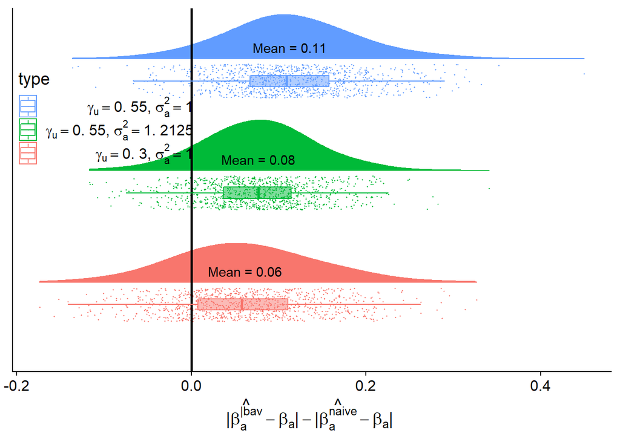

```r
fig_6b(mat_a,mat_a1, mat_b, mat_b1, mat_c, mat_c1, Ba,gu1,gu2,sigA1,sigA2)
```

### Real Data Simulation: Figure 8 Code

First we will load the data. The data can be downloaded at the following link: https://dataverse.no/dataset.xhtml?persistentId=doi:10.18710/R2KJHK

It was puplished originally as part of the study, Examining the effects of an eHealth intervention from infant age 6 to 12 months on child eating behaviors and maternal feeding practices one year after cessation: The Norwegian randomized controlled trial Early Food for Future Health by Helle et al (2019).

To use this code, save the data in SPSS form from the link and call the file “food_24.sav”. Of course you may download it in a different format and load it otherwise then simply code out the first line in the next block.

```r
df <- read.spss("food_24.sav", to.data.frame=TRUE)
```

```
## re-encoding from UTF-8
```

```r
df <- as_tibble(df)
df <- df %>% mutate(A =recode(Group,
                              "intervention" = 1,
                              "control" = 0))

df <- df %>% mutate(Y = df[["CEBQ_EOE"]])


sigX <- .1
sigX_tilda <- 1

X_mat <- data.frame(df$Age_mother,df$CFNS_score,df$CFQ_pressure)

indexer <- (is.na(df$Y)==FALSE)&(is.na(df$CFNS_score)==FALSE)&(is.na(df$CFQ_pressure)==FALSE)&(is.na(df$Age_mother)==FALSE)


cov_mat <- apply(X_mat[indexer,],2,function(x){((x-mean(x))/((1/sigX)*sd(x)))})
X_mat <- X_mat[indexer,]

Y <- df$Y[indexer]
A <- df$A[indexer]
```

Now that the data has been cleaned we can run the unbiased regressions to get the baseline coefficients.

```r
itt <- lm(Y ~ A)

stargazer(itt, type = "html")
```

|  | *Dependent variable:* |
| --- | --- |
|  | Y |
| A | 0.144*** |
|  | (0.053) |
| Constant | 1.467*** |
|  | (0.038) |
| Observations | 294 |
| R<sup>2</sup> | 0.025 |
| Adjusted R<sup>2</sup> | 0.022 |
| Residual Std. Error | 0.452 (df = 292) |
| F Statistic | 7.460*** (df = 1; 292) |
| *Note:* | p<0.1; p<0.05; p<0.01 |

Next we can show that the added covariates do not explain variance in the treatment since it is an experiment.

```r
treat <- lm(A ~ as.matrix(X_mat))

stargazer(treat, type = "html")
```

|  | *Dependent variable:* |
| --- | --- |
|  | A |
| as.matrix(X_mat)df.Age_mother | 0.009 |
|  | (0.007) |
| as.matrix(X_mat)df.CFNS_score | -0.005 |
|  | (0.007) |
| as.matrix(X_mat)df.CFQ_pressure | 0.036 |
|  | (0.040) |
| Constant | 0.200 |
|  | (0.256) |
| Observations | 294 |
| R<sup>2</sup> | 0.010 |
| Adjusted R<sup>2</sup> | -0.001 |
| Residual Std. Error | 0.501 (df = 290) |
| F Statistic | 0.939 (df = 3; 290) |
| *Note:* | p<0.1; p<0.05; p<0.01 |

And finally the outcome regression with covariates

```r
mod_cov <- lm(Y ~ A + as.matrix(X_mat))

stargazer(mod_cov, type = "html")
```

|  | *Dependent variable:* |
| --- | --- |
|  | Y |
| A | 0.137*** |
|  | (0.053) |
| as.matrix(X_mat)df.Age_mother | 0.008 |
|  | (0.006) |
| as.matrix(X_mat)df.CFNS_score | 0.007 |
|  | (0.006) |
| as.matrix(X_mat)df.CFQ_pressure | 0.058 |
|  | (0.036) |
| Constant | 0.996*** |
|  | (0.230) |
| Observations | 294 |
| R<sup>2</sup> | 0.046 |
| Adjusted R<sup>2</sup> | 0.033 |
| Residual Std. Error | 0.450 (df = 289) |
| F Statistic | 3.461*** (df = 4; 289) |
| *Note:* | p<0.1; p<0.05; p<0.01 |

Below is the code to perform the real data sim.

```r
pa <- mean(A)

alpha_a <- -qnorm(1-pa)

cov_a_u <- .25
sigA_star <- 1

cov_a_bav <- c(.22,.15,.13) # This is the covariance we want on the observed space

cov_a_bav2 <- c(.08,.15,.13)

gamma_x2 <- cov_a_bav*sqrt(2*pi)*exp(alpha_a^2/(2*sigA_star^2)) ## See paper for formula for non-zero variables
gamma_x <- cov_a_bav2*sqrt(2*pi)*exp(alpha_a^2/(2*sigA_star^2))

gamma_u <- cov_a_u*sqrt(2*pi)*exp(alpha_a^2/(2*sigA_star^2))

sigBAV <- sqrt(sigX_tilda^2 - sigX^2)
sigU <- 1

sigA_star1 <- sigA_star
sigA_star2 <- sqrt(sigA^2 + (sum(gamma_x2^2) - sum(gamma_x^2))*sigX_tilda^2)
```

```r
### This takes the observed treatment and simulates a latent treatment
a_star_sim2 <- function(A,pa, alpha_a,n,sigA_star){


  X <- runif(n,0,1)

  y <- ((1-pa)^(1-A))*(pa^A)*X + (1-pa)*A

  a_star <- qnorm(y,mean=0,sd=sigA_star) + alpha_a

  a_star
}
```

```r
beta_fun <- function(beta_target,X,Y,A){
  mod <- lm(Y ~ A + X)
  p <- ncol(X)
  beta_x <- coef(mod)[3:(3+(p-1))]
  beta_adj <- beta_target - beta_x
  out <- vector("list", length=2)
  out[[1]] <- beta_adj
  out[[2]] <- beta_x
  out
}
```

```r
n <- length(A)
N <- 100

p <- length(gamma_x)+1
X_mat2 <- apply(X_mat,2,function(x){((x-mean(x))/((1/sigX)*sd(x)))})
Ba <- 0.1377
beta_u <- 0.15
beta_target <- c(0.1,-0.15,-0.1)


output <- vector("list",length=N)
output2 <- vector("list",length=N)
output3 <- vector("list",length=N)
output4 <- vector("list",length=N)
output5 <- vector("list",length=N)
output6 <- vector("list",length=N)
output7 <- vector("list",length=N)
output8 <- vector("list",length=N)
output9 <- vector("list", length=N)
output10 <- vector("list", length=N)

output11 <- vector("list",length=N)
output12 <- vector("list",length=N)
output13 <- vector("list", length=N)
output14 <- vector("list", length=N)

output15 <-  vector("list", length=N)
output16 <-  vector("list", length=N)

output17 <-  vector("list", length=N)
output18 <-  vector("list", length=N)


output19 <-  vector("list", length=N)
output20 <-  vector("list", length=N)
output21 <-  vector("list", length=N)

output22 <-  vector("list", length=N)
output23 <-  vector("list", length=N)
output24 <-  vector("list", length=N)
output25 <-  vector("list", length=N)
```

```r
for(j in 1:N){

  intvec <- c(1:n)
  bootsample <- sample(intvec,n,replace=TRUE)
  A_boot <- A[bootsample]
  Y_boot <- Y[bootsample]
  a_s <- a_star_sim2(A_boot,pa,alpha_a,n,sigA_star1)
  a_s2 <- a_star_sim2(A_boot,pa,alpha_a,n,sigA_star2)

  sigBAV <- sqrt(sigX_tilda^2 - sigX^2)

  cov_boot <- cov_mat[bootsample,]


  Z <- as.matrix(data.frame(a_s,cov_boot))
  Z2 <- as.matrix(data.frame(a_s2,cov_boot))

  sig_zz <- diag(c(sigA_star^2,rep(sigX^2,3)))
  sig_zz2 <- diag(c(sigA_star2^2,rep(sigX^2,3)))

  sig_ww <- diag(c(sigU^2,rep(sigBAV^2,ncol(X_mat2))))
  cov_astar_X <- cov(a_s,cov_boot)
  cov_astar_X2 <- cov(a_s2,cov_boot)


  cov_a_ux <- c(gamma_u*sigU^2,gamma_x*sigX_tilda^2 - 0)
  cov_a_ux2 <- c(gamma_u*sigU^2,gamma_x2*sigX_tilda^2 - 0)

  cov_a_ux3 <- c(gamma_u*sigU^2,gamma_x2*sigX_tilda^2 - 0)

  z_mat <- matrix(nrow = (ncol(X_mat2)+1),ncol = ncol(X_mat2),0)

  sig_wz <- as.matrix(data.frame(cov_a_ux,z_mat))
  sig_wz2 <- as.matrix(data.frame(cov_a_ux2,z_mat))

  sig_wz3 <-  as.matrix(data.frame(cov_a_ux3,z_mat))

  sig_zw <- t(sig_wz)
  sig_zw2 <- t(sig_wz2)
  sig_zw3 <- t(sig_wz3)

  mu_z <- matrix(rep(c(alpha_a,rep(0,ncol(X_mat2))),n),nrow=n,byrow = T)

  mu_w <- matrix(t(sig_wz%*%solve(sig_zz)%*%t(Z - mu_z)),nrow=n)
  mu_w2 <- matrix(t(sig_wz2%*%solve(sig_zz2)%*%t(Z2 - mu_z)),nrow=n)
  mu_w3 <- matrix(t(sig_wz3%*%solve(sig_zz)%*%t(Z - mu_z)),nrow=n)

  sigmat <- sig_ww - sig_wz%*%solve(sig_zz)%*%sig_zw
  sigmat2 <- sig_ww - sig_wz2%*%solve(sig_zz2)%*%sig_zw2
  sigmat3 <- sig_ww - sig_wz3%*%solve(sig_zz)%*%sig_zw3

  UBAV <- matrix(nrow=n,ncol =p,0)
  UBAV2 <- matrix(nrow=n,ncol =p,0)
  UBAV3 <- matrix(nrow=n,ncol=p,0)

  for(i in 1:n){
    UBAV[i,] <- mvrnorm(1,mu=mu_w[i,],Sigma=sigmat)
    UBAV2[i,] <- mvrnorm(1,mu=mu_w2[i,],Sigma=sigmat2)
    UBAV3[i,] <- mvrnorm(1,mu = mu_w3[i,],Sigma=sigmat3)
  }

  X_tild <- UBAV[,2:4] + cov_boot
  X_tild2 <- UBAV2[,2:4] + cov_boot
  X_tild3 <- UBAV3[,2:4] + cov_boot

  beta_list <- beta_fun(beta_target,cov_boot,Y_boot,A_boot)
  beta_adj <- as.matrix(beta_list[[1]])
  beta_x <- as.matrix(beta_list[[2]])


  Y_tild <- Y_boot + UBAV[,1]*beta_u + UBAV[,2:4]%*%beta_x + X_tild%*%beta_adj
  Y_tild2 <- Y_boot + UBAV2[,1]*beta_u + UBAV2[,2:4]%*%beta_x + X_tild2%*%beta_adj
  Y_tild3 <- Y_boot + UBAV3[,1]*beta_u + UBAV3[,2:4]%*%beta_x + X_tild3%*%beta_adj

  cov_boot2 <- cov_boot*sqrt(2)

  output[[j]] <- var(UBAV)
  output2[[j]] <- cov_astar_X
  mod <- lm(a_s ~ X_tild)
  mod2 <- lm(Y_tild ~ X_tild + UBAV[,1])
  mod3 <- lm(Y_tild ~ A_boot + X_tild + UBAV[,1])
  mod4 <- lm(Y_tild ~ A_boot)
  mod5 <- lm(Y_tild ~ A_boot + X_tild)
  mod6 <- lm(Y_tild2 ~ A_boot + X_tild2 + UBAV2[,1])
  mod7 <- lm(Y_tild2 ~ A_boot + X_tild2)
  mod8 <- lm(Y_tild2 ~ A_boot)


  mod9 <- lm(A_boot ~ X_tild + UBAV[,1])
  mod10 <- lm(A_boot ~ X_tild2 + UBAV2[,1])

  mod11 <- lm(a_s ~ X_tild + UBAV[,1])
  mod12 <- lm(a_s2 ~ X_tild2 + UBAV2[,1])

  mod13 <- lm(Y_tild3 ~ A_boot + X_tild3 + UBAV3[,1])
  mod14 <- lm(Y_tild3 ~ A_boot + X_tild3)
  mod15 <- lm(Y_tild3 ~ A_boot)

  mod16 <- lm(a_s ~ X_tild3 + UBAV3[,1])

  output3[[j]] <- coef(mod)
  output4[[j]] <- coef(mod2)
  output5[[j]] <- coef(mod3)
  output6[[j]] <- coef(mod4)
  output7[[j]] <- coef(mod5)
  output8[[j]] <- coef(mod6)
  output9[[j]] <- coef(mod7)
  output10[[j]] <- coef(mod8)
  output11[[j]] <- coef(mod9)
  output12[[j]] <- coef(mod10)
  output13[[j]] <- var(UBAV2)
  output14[[j]] <- cov_astar_X2

  output15[[j]] <- coef(mod11)
  output16[[j]] <- coef(mod12)

  output17[[j]] <- coef(mod13)
  output18[[j]] <- coef(mod14)
  output19[[j]] <- coef(mod15)

  output20[[j]] <- coef(mod16)

  output21[[j]] <- var(UBAV3)

  output22[[j]] <- var(X_tild)
  output23[[j]] <- var(X_tild2)
  output24[[j]] <- var(X_tild3)



}
```

```r
mat3 <- matrix( unlist(output3) , nrow=N, ncol = 4,byrow = T)
mat4 <- matrix(unlist(output4),nrow=N, ncol = 5,byrow = T)
mat5 <- matrix(unlist(output5),nrow=N, ncol = 6,byrow = T)
mat6 <- matrix(unlist(output6),nrow=N, ncol = 2,byrow = T)
mat7 <- matrix(unlist(output7),nrow=N, ncol = 5,byrow = T)
mat8 <- matrix(unlist(output8),nrow=N, ncol = 6,byrow = T)
mat9 <- matrix(unlist(output9),nrow=N,ncol = 5,byrow=T)
mat10 <- matrix(unlist(output10),nrow=N, ncol=2,byrow=T)


#mat15 <- matrix(unlist(output15),nrow=N, ncol=5,byrow=T)
#mat16 <- matrix(unlist(output16),nrow=N, ncol=5,byrow=T)

mat17 <- matrix(unlist(output17),nrow=N, ncol=6,byrow=T)
mat18 <- matrix(unlist(output18),nrow=N, ncol=5,byrow=T)

mat19 <- matrix(unlist(output19),nrow=N, ncol=2,byrow=T)
mat20 <- matrix(unlist(output20),nrow=N, ncol=5,byrow=T)
```

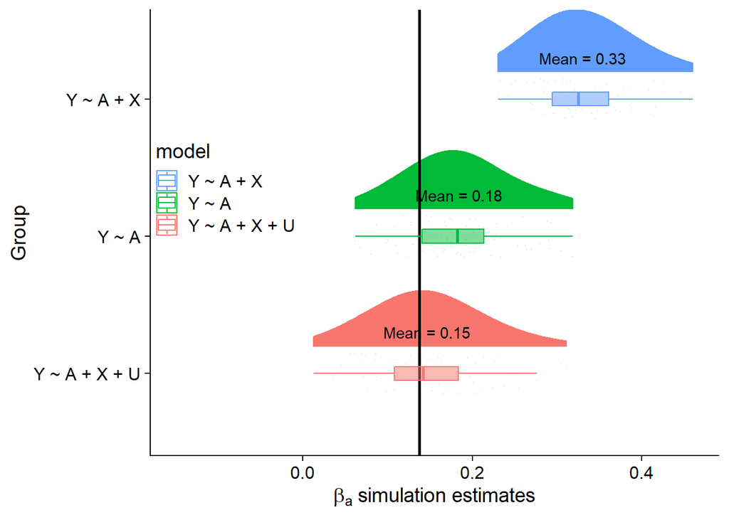

```r
df1 <- data.frame(Ba = mat5[,2], model = "Y ~ A + X + U",type = "Y1")
df2 <- data.frame(Ba = mat6[,2], model = "Y ~ A",type = "Y1")
df3 <- data.frame(Ba = mat7[,2], model = "Y ~ A + X", type = "Y1")

df4 <- data.frame(Ba = mat8[,2], model = "Y ~ A + X + U", type = "Y2")
df5 <- data.frame(Ba = mat9[,2], model = "Y ~ A + X", type = "Y2")
df6 <- data.frame(Ba = mat10[,2], model = "Y ~ A", type = "Y2")

df7 <- data.frame(Ba = mat17[,2], model = "Y ~ A + X + U", type = "Y3")
df8 <- data.frame(Ba = mat18[,2], model = "Y ~ A + X", type = "Y3")
df9 <- data.frame(Ba = mat19[,2], model = "Y ~ A", type = "Y3")

df_full <- rbind(df1,df2,df3,df4,df5,df6,df7,df8,df9)

df_full_s <- rbind(df1,df2,df3)

df_f2 <- rbind(df4,df5,df6,df7,df8,df9)

df_f2 <- df_f2 %>%
  mutate(model = fct_reorder(model,Ba, .fun = 'mean'))

m1 <- mean(mat5[,2])
m2 <- mean(mat6[,2])
m3 <- mean(mat7[,2])

m4 <- mean(mat8[,2])
m5 <- mean(mat9[,2])
m6 <- mean(mat10[,2])

m7 <- mean(mat17[,2])
m8 <- mean(mat18[,2])
m9 <- mean(mat19[,2])

df_full2 <- df_full %>%
  mutate(model = fct_reorder(model,Ba, .fun = 'mean'))

df_full_s2 <- df_full_s %>%
  mutate(model = fct_reorder(model,Ba, .fun = 'mean'))

ggplot(df_full_s2,aes(x=model,y=Ba, fill = model,col = model))+
  geom_flat_violin(position = position_nudge(x = .2, y = 0),adjust =
                     2)+
  geom_point(position = position_jitter(width = .15), size = .01,alpha=.1)+
  ylab(TeX(paste0("$\\beta_a$", " simulation estimates")))+xlab('Group')+coord_flip()+theme_cowplot()+guides(fill = FALSE)+


  geom_hline(yintercept = 0.1377,size =1)+
  geom_boxplot(width = .1, guides = FALSE, outlier.shape = NA, alpha = 0.5)+
  theme(legend.position = c(0.01, 0.6))+
  expand_limits(y= -.15) + annotate("text", label = paste0("Mean = ",round(m3,2)),x= 3.3, y= m3, color = "black")+
  annotate("text", label = paste0("Mean = ",round(m2,2)),x= 2.3, y= m2, color = "black")+
  annotate("text", label = paste0("Mean = ",round(m1,2)),x= 1.3, y= m1, color = "black")+
  annotate("text", label = paste0)+
  scale_colour_discrete(guide = guide_legend(reverse = TRUE))
```